# Netify: Manual Plotting with ggplot2

Cassy Dorff and Shahryar Minhas

2024-05-21

This vignette provides an overview of how to create customizable plots using `ggplot2` while still using `netify` to prepare the data.

Lets load the necessary libraries.

```r
library(netify)
library(ggplot2)
```

We’ll also use the `ggnewscale` package to create multiple legends when necessary in the same plot (e.g., if you want to have legends for a color aesthetic for both nodes and edges).

```r
if(!'ggnewscale' %in% rownames(installed.packages())){
  install.packages('ggnewscale', repos='https://cloud.r-project.org') }
library(ggnewscale)
```

## Preparing data

First lets create a `netlet` object from some dyadic data (ICEWS data) using the `netify` package.

```r
# load icews data
data(icews)

# choose attributes
nvars = c( 'i_polity2', 'i_log_gdp', 'i_log_pop' )
dvars = c( 'matlCoop', 'verbConf', 'matlConf' )

# create a netify object
netlet = netify(
    dyad_data=icews, actor1='i', actor2='j',
    time = 'year',
    symmetric=FALSE, weight='verbCoop',
    mode='unipartite', sum_dyads=FALSE,
    actor_time_uniform=TRUE, actor_pds=NULL,
    diag_to_NA=TRUE, missing_to_zero=TRUE,
    nodal_vars = nvars,
    dyad_vars = dvars
)

# subset to a few actors
actors_to_keep = c(
  'Australia', 'Brazil',
  'Canada', 'Chile', 'China',
  'Colombia', 'Egypt', 'Ethiopia',
  'France', 'Germany', 'Ghana',
  'Hungary', 'India', 'Indonesia',
  'Iran, Islamic Republic Of',
  'Israel', 'Italy', 'Japan', 'Kenya',
  "Korea, Democratic People's Republic Of",
  'Korea, Republic Of', 'Nigeria', 'Pakistan',
  'Qatar', 'Russian Federation', 'Saudi Arabia',
  'South Africa', 'Spain', 'Sudan',
  'Syrian Arab Republic', 'Thailand',
  'United Kingdom', 'United States',
  'Zimbabwe' )
netlet = subset_netlet(
  netlet,
  what_to_subset = actors_to_keep
)

# print
netlet
```

```
## ✔ Hello, you have created network data, yay!
```

```
## • Longitudinal
```

```
## • Unipartite
```

```
## • Asymmetric
```

```
## • Weights from `verbCoop`
```

```
## • No Loops Allowed
```

```
## • Longitudinal: 13 Periods
```

```
## • # Unique Row Actors: 34
```

```
## • # Unique Column Actors: 34
```

```
## • # Unique Actors: 34
```

```
##            nLoops nEdges  density     recip propNA
## 1 verbCoop    N/A  12937 179.4837 0.9785963    N/A
```

```
## • Nodal Features: i_polity2, i_log_gdp, i_log_pop
```

```
## • Dyad Features: matlCoop, verbConf, matlConf
```

```
## • Graph Features: None
```

This is a longitudinal, weighted network with nodal and dyadic attributes. In a few more steps we will show how to highlight these attributes in the plot.

Next, we use the `net_plot_data` function to create a data frame for `ggplot2`. `net_plot_data` extracts and sets up node and edge data from a `netify` object according to specified plotting arguments. It returns a list of different components but the most important one for users is the `net_dfs` element. This element contains two objects: `edge_data` and `nodal_data`. These are data frames that can be passed to `ggplot2`.

```r
# create a data frame for plotting
plot_data = net_plot_data(netlet)

# get relevant dfs
net_dfs = plot_data$net_dfs

# check structure of what's here
str(net_dfs)
```

```
## List of 2
##  $ edge_data :'data.frame':  12937 obs. of  11 variables:
##   ..$ from    : chr [1:12937] "Australia" "Australia" "Australia" "Australia" ...
##   ..$ to      : chr [1:12937] "Brazil" "Brazil" "Brazil" "Brazil" ...
##   ..$ time    : chr [1:12937] "2002" "2003" "2004" "2005" ...
##   ..$ verbCoop: num [1:12937] 3 3 24 27 54 4 26 7 12 5 ...
##   ..$ matlCoop: num [1:12937] 0 1 0 0 0 0 0 0 1 0 ...
##   ..$ verbConf: num [1:12937] 0 2 0 2 3 0 2 1 0 0 ...
##   ..$ matlConf: num [1:12937] 0 0 2 0 1 0 0 0 0 0 ...
##   ..$ x1      : num [1:12937] -3.187 -0.3978 -0.0496 -0.3853 -0.5135 ...
##   ..$ y1      : num [1:12937] 2.535 -1.3386 0.0651 0.9399 1.4266 ...
##   ..$ x2      : num [1:12937] -2.9515 -0.0649 -0.0429 -0.2949 -0.3298 ...
##   ..$ y2      : num [1:12937] 2.315 -1.441 -0.148 1.045 1.485 ...
##  $ nodal_data:'data.frame':  442 obs. of  10 variables:
##   ..$ name      : chr [1:442] "Australia" "Australia" "Australia" "Australia" ...
##   ..$ time      : chr [1:442] "2002" "2003" "2004" "2005" ...
##   ..$ i_polity2 : int [1:442] 10 10 10 10 10 10 10 10 10 10 ...
##   ..$ i_log_gdp : num [1:442] 27.6 27.6 27.6 27.7 27.7 ...
##   ..$ i_log_pop : num [1:442] 16.8 16.8 16.8 16.8 16.8 ...
##   ..$ x         : num [1:442] -3.187 -0.3978 -0.0496 -0.3853 -0.5135 ...
##   ..$ y         : num [1:442] 2.535 -1.3386 0.0651 0.9399 1.4266 ...
##   ..$ name_text : chr [1:442] "Australia" "Australia" "Australia" "Australia" ...
##   ..$ name_label: chr [1:442] "Australia" "Australia" "Australia" "Australia" ...
##   ..$ id        : chr [1:442] "Australia_2002" "Australia_2003" "Australia_2004" "Australia_2005" ...
```

```r
# check the first few rows of the edge data
head(net_dfs$edge_data)
```

```
##        from     to time verbCoop matlCoop verbConf matlConf          x1
## 1 Australia Brazil 2002        3        0        0        0 -3.18695808
## 2 Australia Brazil 2003        3        1        2        0 -0.39782446
## 3 Australia Brazil 2004       24        0        0        2 -0.04957632
## 4 Australia Brazil 2005       27        0        2        0 -0.38526735
## 5 Australia Brazil 2006       54        0        3        1 -0.51353531
## 6 Australia Brazil 2007        4        0        0        0 -0.69085788
##            y1          x2         y2
## 1  2.53500179 -2.95152256  2.3151148
## 2 -1.33861627 -0.06486153 -1.4411348
## 3  0.06513246 -0.04293486 -0.1479501
## 4  0.93989844 -0.29488038  1.0449019
## 5  1.42660061 -0.32983771  1.4847187
## 6  1.79965809 -0.86547402  1.7542202
```

```r
# check the first few rows of the nodal data
head(net_dfs$nodal_data)
```

```
##        name time i_polity2 i_log_gdp i_log_pop           x           y
## 1 Australia 2002        10  27.55492  16.78568 -3.18695808  2.53500179
## 2 Australia 2003        10  27.58556  16.79718 -0.39782446 -1.33861627
## 3 Australia 2004        10  27.62686  16.80787 -0.04957632  0.06513246
## 4 Australia 2005        10  27.65791  16.82005 -0.38526735  0.93989844
## 5 Australia 2006        10  27.68495  16.83354 -0.51353531  1.42660061
## 6 Australia 2007        10  27.72203  16.85179 -0.69085788  1.79965809
##   name_text name_label             id
## 1 Australia  Australia Australia_2002
## 2 Australia  Australia Australia_2003
## 3 Australia  Australia Australia_2004
## 4 Australia  Australia Australia_2005
## 5 Australia  Australia Australia_2006
## 6 Australia  Australia Australia_2007
```

The `x` and `y` in `nodal_data` and the `x1`, `y1`, `x2`, and `y2` in `edge_data` are the coordinates of the nodes and edges, respectively. These are the coordinates that will be used to plot the network.

## Creating a plot

Now that we have the data, we can create a plot using `ggplot2`. We’ll use the `geom_segment` and `geom_point` (or, `geom_label`, `geom_text`, and the `ggrepel package equivalents) functions to plot the edges and nodes, respectively.

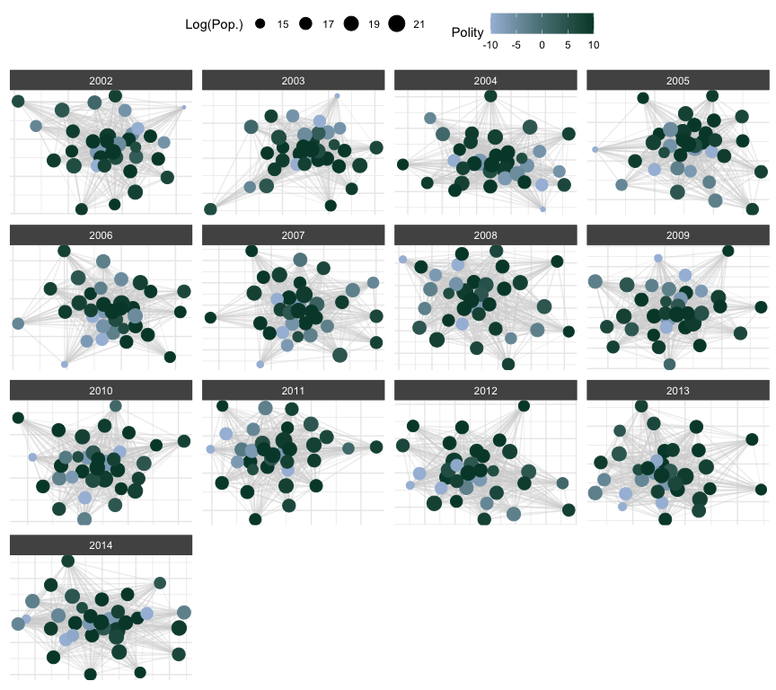

```r
ggplot() +
    geom_segment(
        data = net_dfs$edge_data,
        aes(
            x=x1,
            y=y1,
            xend=x2,
            yend=y2
        ),
        color='lightgrey',
        alpha=.2
    ) +
    geom_point(
        data = net_dfs$nodal_data,
        aes(
            x=x,
            y=y,
            size=i_log_pop,
            color=i_polity2
        )
    ) +
  labs(
    color='Polity',
    size='Log(Pop.)'
  ) +
    scale_color_gradient(low='#a6bddb', high='#014636') +
    facet_wrap(~time, scales='free') +
    theme_netify()
```

### Changing the layout

By default layouts for node positions are drawn from the `layout_nicely` algorithm in the `igraph` package. Users can specify other layouts as, for example, say that you wanted to use the `mds` algorithm instead:

```r
# create a df using fr instead
plot_data_mds = net_plot_data(netlet,
    list(
        layout='mds'
        )
    )

# see new x-y coordinates
lapply(plot_data_mds$net_dfs, head)
```

```
## $edge_data
##        from     to time verbCoop matlCoop verbConf matlConf          x1
## 1 Australia Brazil 2002        3        0        0        0 -0.35485450
## 2 Australia Brazil 2003        3        1        2        0  0.20857397
## 3 Australia Brazil 2004       24        0        0        2 -0.04224981
## 4 Australia Brazil 2005       27        0        2        0 -0.06014447
## 5 Australia Brazil 2006       54        0        3        1  0.15073774
## 6 Australia Brazil 2007        4        0        0        0 -0.03161665
##            y1         x2         y2
## 1 -0.16803048 -0.7281113  0.3619659
## 2 -0.12705283  0.2552975 -0.1025320
## 3  0.05123628  0.2101186  0.9327511
## 4 -0.02708750  0.4552562  0.1927606
## 5  0.46114648  0.1278155  0.3895673
## 6 -0.03885021 -0.3606698  0.8028908
```

[output cut: 16 more lines]

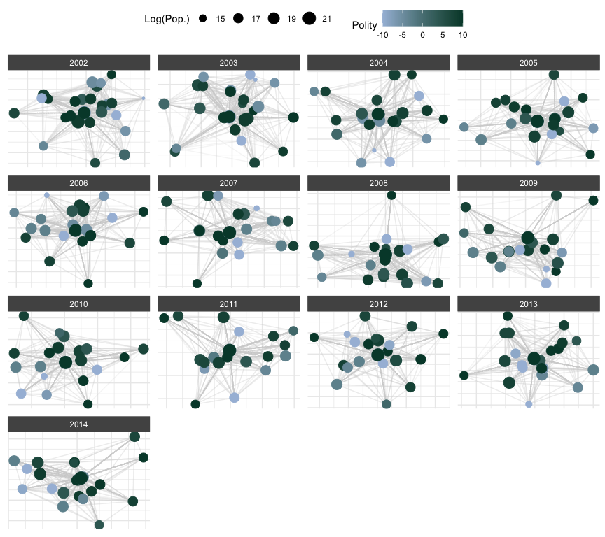

```r
# get relevant dfs
net_dfs_kk = plot_data_mds$net_dfs

# plot
ggplot() +
    geom_segment(
        data = net_dfs_kk$edge_data,
        aes(
            x=x1,
            y=y1,
            xend=x2,
            yend=y2
        ),
        color='lightgrey',
        alpha=.2
    ) +
    geom_point(
        data = net_dfs_kk$nodal_data,
        aes(
            x=x,
            y=y,
            size=i_log_pop,
            color=i_polity2
        )
    ) +
    scale_color_gradient(low='#a6bddb', high='#014636') +
  labs(
    size='Log(Pop.)',
    color='Polity'
  ) +
    facet_wrap(~time, scales='free') +
    theme_netify()
```

```r
#
```

### Add Edge Information

So far, we have focused on using color to convey information about nodal attributes in the network (population size and polity score). Now, let’s add more edge information to the plot. For example, we can include information about the `matlConf` dyadic attribute. Imagine we want to highlight edges of verbal cooperation that occur at the same time as when higher than average levels of material conflict occur in the network. First, let’s create the variable in the edge data.

```r
if(!'dplyr' %in% rownames(installed.packages())){
  install.packages('dplyr', repos='https://cloud.r-project.org') }
library(dplyr)
# create high_matlConf variable
net_dfs$edge_data = net_dfs$edge_data |>
    group_by(time) |>
    mutate(
        high_matlConf = matlConf > mean(matlConf, na.rm=TRUE)
    ) |>
    ungroup() |>
    as.data.frame()

# check
head(net_dfs$edge_data)
```

```
##        from     to time verbCoop matlCoop verbConf matlConf          x1
## 1 Australia Brazil 2002        3        0        0        0 -3.18695808
## 2 Australia Brazil 2003        3        1        2        0 -0.39782446
## 3 Australia Brazil 2004       24        0        0        2 -0.04957632
## 4 Australia Brazil 2005       27        0        2        0 -0.38526735
## 5 Australia Brazil 2006       54        0        3        1 -0.51353531
## 6 Australia Brazil 2007        4        0        0        0 -0.69085788
##            y1          x2         y2 high_matlConf
## 1  2.53500179 -2.95152256  2.3151148         FALSE
## 2 -1.33861627 -0.06486153 -1.4411348         FALSE
## 3  0.06513246 -0.04293486 -0.1479501         FALSE
## 4  0.93989844 -0.29488038  1.0449019         FALSE
## 5  1.42660061 -0.32983771  1.4847187         FALSE
## 6  1.79965809 -0.86547402  1.7542202         FALSE
```

Now that we have the new variable in the data.frame, we can plot by it but note that we now need a color aesthetic for both points and segments, even though `ggplot2` only supports one legend by aesthetic by default. We can get around this by using the `new_scale_color` function from the ``ggnewscale` package.

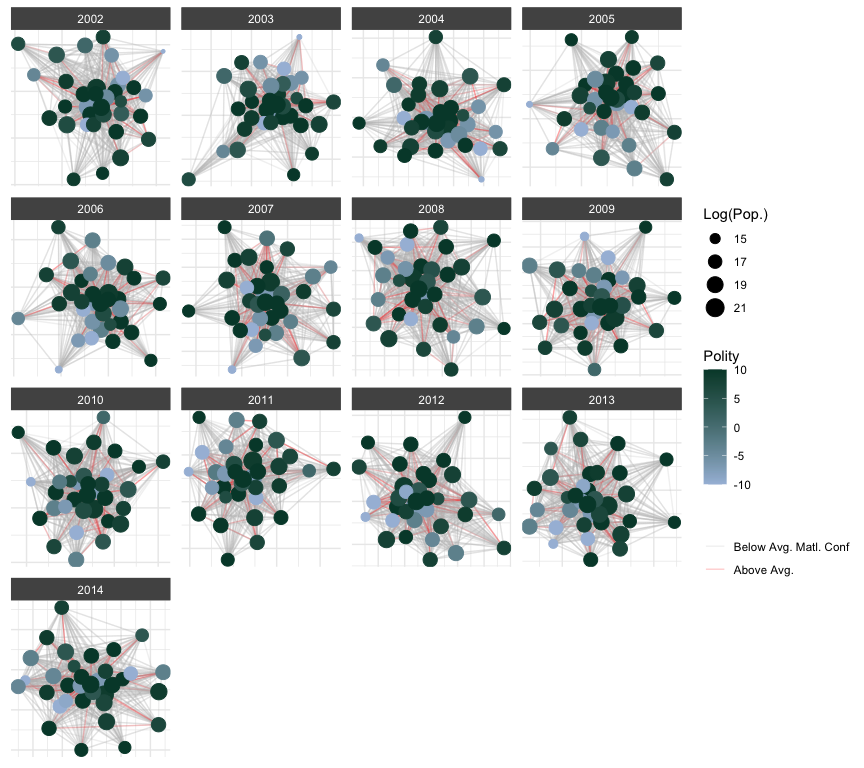

```r
# color line segments by this new variable
ggplot() +
    geom_segment(
        data = net_dfs$edge_data,
        aes(
            x=x1,
            y=y1,
            xend=x2,
            yend=y2,
            color=high_matlConf
        ),
        alpha=.2
    ) +
    scale_color_manual(
      name='',
      values=c('grey', 'red'),
      labels=c('Below Avg. Matl. Conf', 'Above Avg.')
      ) +
    new_scale_color() +
    geom_point(
        data = net_dfs$nodal_data,
        aes(
            x=x,
            y=y,
            size=i_log_pop,
            color=i_polity2
        )
    ) +
    scale_color_gradient(
      name='Polity',
      low='#a6bddb', high='#014636') +
  labs(
    size='Log(Pop.)'
  ) +
    facet_wrap(~time, scales='free') +
    theme_netify() +
  theme(
    legend.position='right'
  )
```

## References

- Boschee, Elizabeth; Lautenschlager, Jennifer; O’Brien, Sean; Shellman, Steve; Starz, James; Ward, Michael, 2015, ``ICEWS Coded Event Data’’, doi:10.7910/DVN/28075 , Harvard Dataverse.
- Pedersen, T. L. (2020). ggnewscale: Multiple Fill and Colour Scales in ‘ggplot2’. R package version 0.4.3. https://CRAN.R-project.org/package=ggnewscale
- Wickham, H. (2016). ggplot2: Elegant Graphics for Data Analysis. Springer-Verlag New York.